# Lab 4 Assignment

## Problem 1:

Use simulation to answer the following questions.

Given independent uniform random variables $X_1 \sim U(a, b)$ and $X_2 \sim U(a,b)$. (You can use parameters of your choice)

*a.* Is the distribution of $X_1 +X_2$ uniform? Please Justify your answer.

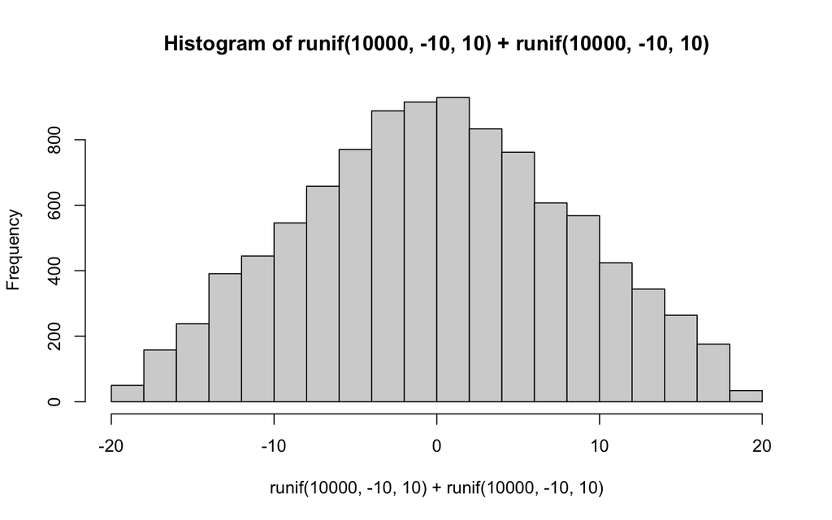

```r
hist(runif(10000,-10,10)+runif(10000,-10,10))
```

The histogram shows that adding the two distributions doesn’t give us a uniform distribution. This is expected as there are more combinations to get 0 than there are to get +/-20.

*b.* Is the distribution of $X_1.X_2$ uniform? Please Justify your answer.

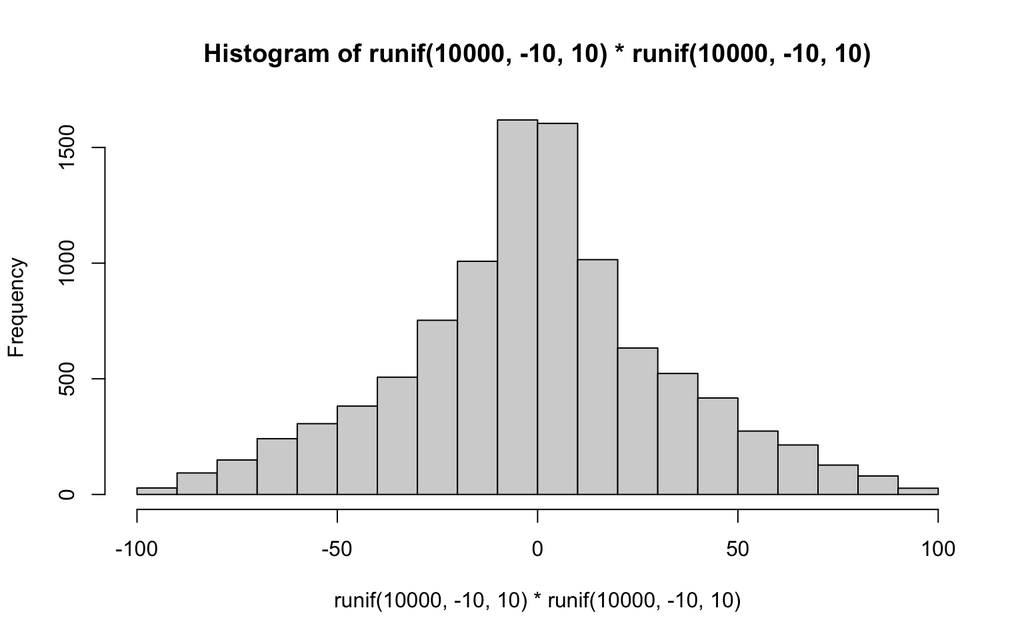

```r
hist(runif(10000,-10,10)*runif(10000,-10,10))
```

*c.* Is the distribution of $max(X_1, X_2)$ or $min(X_1, X_2)$ uniform? Please Justify your answer.

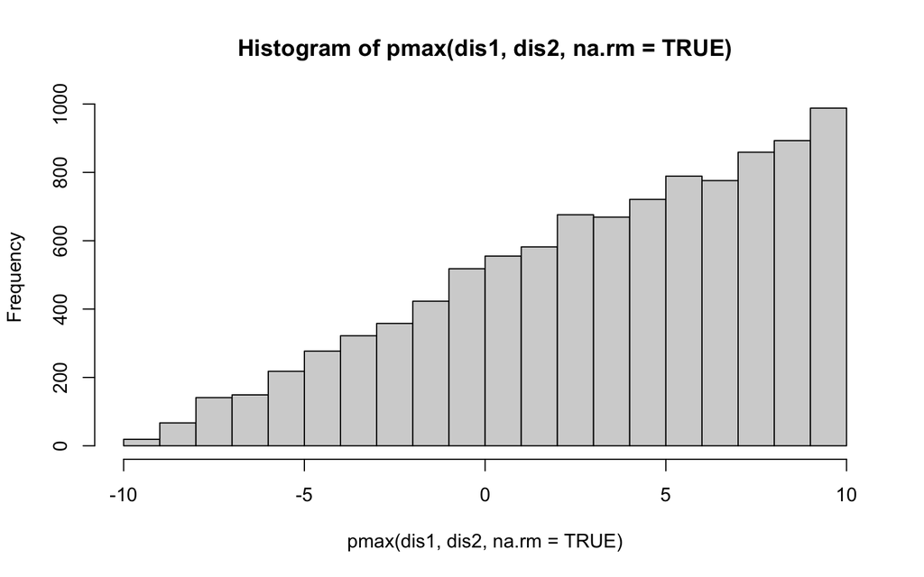

```r
dis1 <- runif(10000,-10,10)
dis2 <- runif(10000,-10,10)
hist(pmax(dis1, dis2, na.rm = TRUE))
```

The histogram shows that there will be a tendency of higher values appearing more often. Logically, if we’re taking the maximum value of each pair of instances from the distributions, the only way for -10 to appear would be for both to be -10. On the other hand, 10 will always be picked as the highest number.

*d.* Is the distribution of $1-X_1$ uniform? Please Justify your answer.

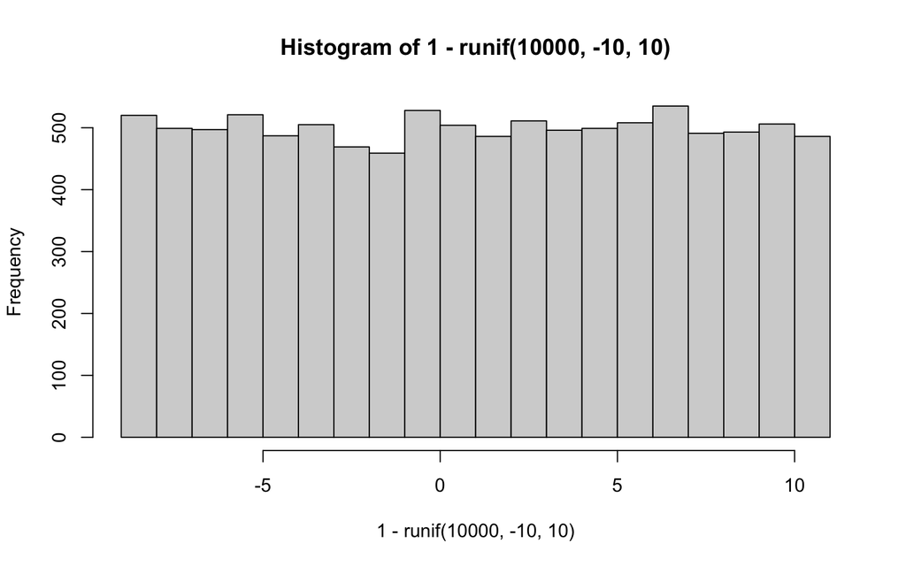

```r
hist(1-runif(10000,-10,10))
```

## Problem 2:

Prove the following theorems using simulation. (You can use parameters of your choice)

1. Linear Transformations

[figure not shown]

```r
# create variable of 100 random, normal numbers. find mean, variance, and standard deviation
X = rnorm(100)
Xmean = mean(X)
Xvar = var(X)
Xstd = sqrt(Xvar)

# define a and b. define Y with a, b, and the created distribution
a = 1
b = 5
Y = a*X + b

# proving that mean of Y is the same as a*mean(X)+b
mean(Y)
```

```
## [1] 4.914275
```

```r
a*Xmean+b
```

```
## [1] 4.914275
```

```r
# proving that the variance for Y is the same as a^2*variance
var(Y)
```

```
## [1] 0.9880915
```

```r
a**2*Xvar
```

```
## [1] 0.9880915
```

Finding the variance and mean in both ways shows that the aforementioned theorem is correct.

2. Linear Combinations of Normally Distributed Variables

[figure not shown]

```r
s=10000
iterations=10
mus <- c(0,1,2,3,4,5,6,7,8,9)
sds <- c(1,2,3,4,5,6,7,8,9,10)
df <- data.frame(matrix(data=NA, nrow=s, ncol=iterations))
for (i in 1:10){
  df[i] <- rnorm(s, mus[i], sds[i])
}
# sum the rows
x <- rowSums(df)
# mean of distribution
mean(x)
```

```
## [1] 45.03054
```

```r
# sum of distribution means
sum(mus)
```

```
## [1] 45
```

```r
# variance of distribution
var(x)
```

```
## [1] 386.2861
```

```r
# sum of variances
sum(sds^2)
```

```
## [1] 385
```

Mean and sum of means is very similar, maybe with more simulations we can get it close to exactly the same. The same goes for variances.

## Problem 3:

Use the iris data set to check the normality of Sepal width of setosa using the following normality tests (Repeat the steps in the example 3 in lab 4, comment on your results)

1. Anderson Darling Test

```r
df <- read.csv('/Users/modeedna/Desktop/SCHOOLS/GEORGETOWN/511 PROB/Lab 4/iris.csv')
library(nortest)
setosa <- df[df$variety=='Setosa',]
ad.test(setosa$sepal.width)
```

```
##
##  Anderson-Darling normality test
##
## data:  setosa$sepal.width
## A = 0.49096, p-value = 0.2102
```

Given that the p-value is over 0.05, we can confirm that the distribution is normal.

2. Kolmogorov-Smirnov Test (Compare to a standard normal distribution)

```r
ks.test(setosa$sepal.width,'pnorm',mean(setosa$sepal.width),sqrt(var(setosa$sepal.width)))
```

```
##
##  Asymptotic one-sample Kolmogorov-Smirnov test
##
## data:  setosa$sepal.width
## D = 0.10468, p-value = 0.6437
## alternative hypothesis: two-sided
```

According to this test, it’s normally distributed. I used the mean and standard deviation of the variable and compared it to a normal distribution. The p-value shows that it is indeed normally distributed.

## Problem 4 (BONUS): Exponential Distribution

Given exponentially distributed random variables $X_1, . . . , X_k$ . Think of waiting times for independent random alarm clocks $1,...,k$ to go off.

Which of these are again exponentially distributed? Explore with a simulation. (Hint: you can use many methods here to compare the distributions, for example; using Kolmogorov-Smirnov Test, plotting cdfs or ecdfs(as we did in lab 3),..etc )

1. Distribution of $min(X_1,\dots,X_k)$? Waiting time for the first alarm to go off.

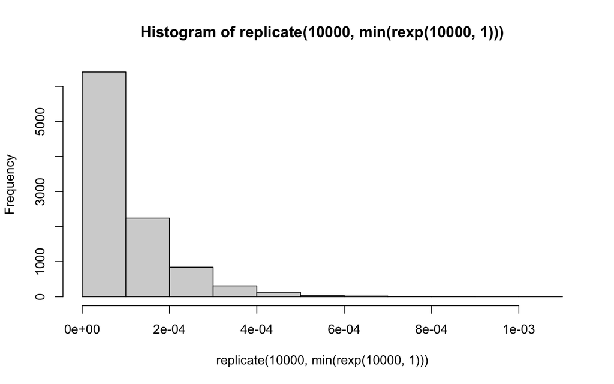

```r
hist(replicate(10000,min(rexp(10000,1))))
```

The distribution of the mins remains an exponential distribution, as evidenced by the histogram.

2. Distribution of $max(X_1, \dots, X_k )$? Waiting time for the last alarm to go off.

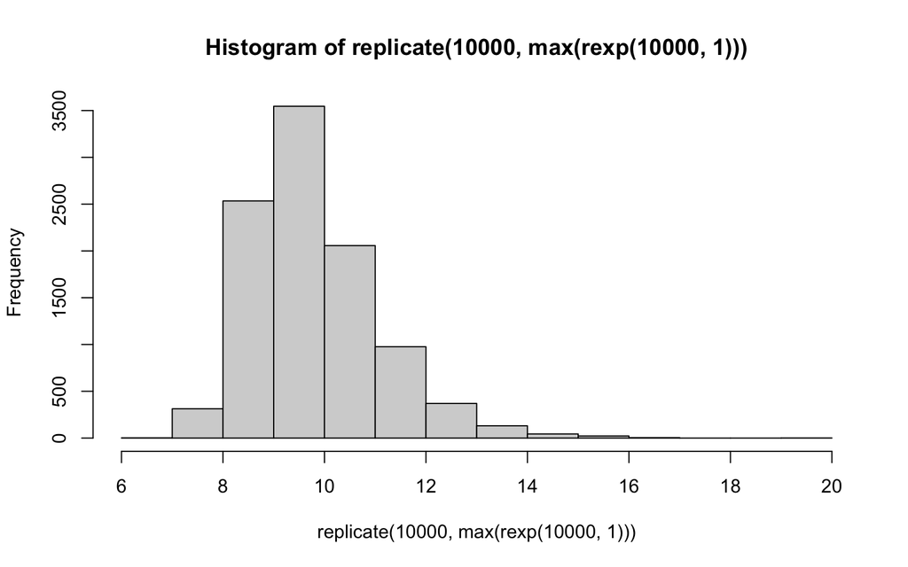

```r
hist(replicate(10000,max(rexp(10000,1))))
```

The distribution for the maxes gets close to an exponential distribution, but is closer to a normal distribution with a long/heavy right tail, as evidenced by the histogram.

3. Distribution of $X_1 + \dots + X_k$ ? Waiting time until Start of the next clock when the previous alarm/s has gone off.

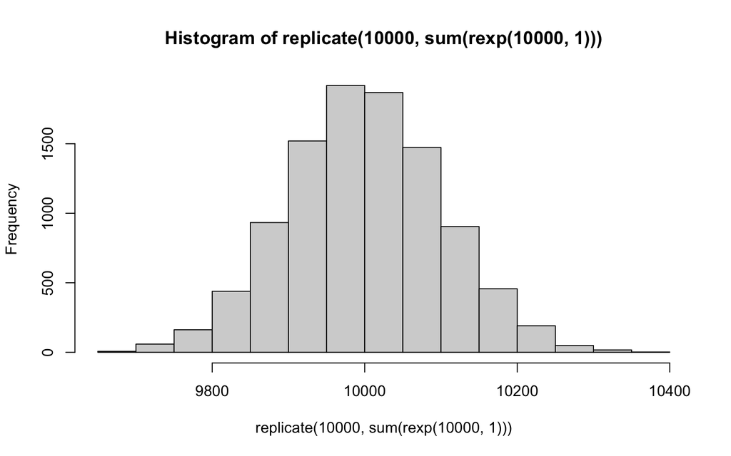

```r
hist(replicate(10000,sum(rexp(10000,1))))
```

The distribution for the sums is a normal distribution, shown by the historgam.